# DGP Dossier: synth_hd_sparse_plm

## 1. Identity & Status

[output not shown]

## 2. What This DGP Stresses (Intent)

Sparsity and regularization in high dimensions. Tests whether estimators can recover a sparse linear signal without overfitting. Toeplitz correlation ($\rho = 0.95$) increases collinearity and makes nuisance learning fragile, but overlap is restored to be moderate in v1.5.0 so the primary stress is high-dimensional sparsity rather than positivity.

## 3. Identification Assumptions (Explicit)

- Selection on observables holds.
- Overlap is moderate.
- SUTVA holds.

## 4. Mathematical Specification

Covariates:
$$X \in \mathbb{R}^{100},\quad X \sim \mathcal{N}(0, \Sigma),\quad
\Sigma_{ij} = 0.95^{|i-j|}$$

Outcome (control):
$$\mu_0(X) = \sum_{j=1}^{5} X_j$$

Propensity:
$$\text{logit}(p(X)) = 0.2\sum_{j=1}^{5} X_j$$

Treatment effect:
$$\tau(X) \equiv 1$$

Noise:
$$\varepsilon \sim \mathcal{N}(0, 1^2)$$

## 5. Oracle Truth Definition

- True ATT is computed from `structural_te` among treated units.
- True QST is computed on the oracle tau grid (`cs_get_oracle_qst()`).

## 6. Visual Diagnostics (n = 5000)

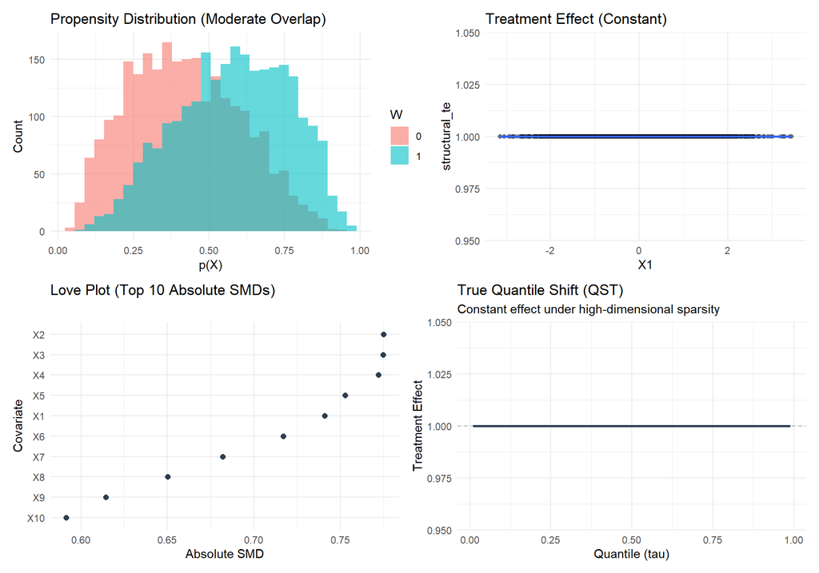

## 7. Empirical Validation

`lm_att` serves as the baseline: it matches the sparse linear outcome model.

**Victim:** `ipw_att` uses standard (unregularized) logistic regression for the propensity model. In $P=100$ with $\rho=0.95$, collinearity and low N/P can still make nuisance estimation fragile, but v1.5.0 restores moderate overlap so the primary stress is high-dimensional sparsity rather than positivity.

| estimator_id | mean_bias | rmse |
| --- | --- | --- |
| ipw_att | -0.166 | 1.105 |
| lm_att | 0.032 | 0.118 |
| oracle_att | 0.000 | 0.000 |

## 8. Failure Mode Summary

- High-dimensional nuisance estimation can drown out the sparse signal.
- Non-parametric methods that fit complex nuisance surfaces can degrade sharply in 100D.

## 9. Implementation Reference

- Generator: `R/dgp-synth-hd-sparse-plm.R`
- Registry: `cs_dgp_registry()` entry for `synth_hd_sparse_plm`
- Oracle truth: `cs_get_oracle_qst("synth_hd_sparse_plm", version = "1.5.0")`

## 10. Validation Checklist

- Toeplitz covariance specified
- Sparse outcome/propensity specified
- Love plot replaces X1 vs X2 scatter

## 11. Changelog

- v1.4.0: Parameter hardening (Deprecated v1.3.0).
- v1.5.0: Reduced propensity coefficients to 0.2. v1.4.0 deprecated due to unintended positivity violation caused by correlation inflation.

## Appendix: Implementation

```
Source code for: dgp_synth_hd_sparse_plm_v150

function(n, seed = NULL, include_truth = TRUE, oracle_only = FALSE) {
  if (!is.null(seed)) {
    cs_set_rng(seed)
  }

  p_hd <- 100L
  idx <- seq_len(p_hd)
  Sigma <- outer(idx, idx, function(i, j) 0.95 ^ abs(i - j))
  L <- chol(Sigma)
  Z <- matrix(stats::rnorm(n * p_hd), nrow = n)
  X <- Z %*% L

  colnames(X) <- paste0("X", seq_len(p_hd))

  beta_y <- c(rep(1, 5), rep(0, p_hd - 5))
  mu0    <- as.numeric(X %*% beta_y)
  eps    <- stats::rnorm(n, mean = 0, sd = 1)
  y0     <- mu0 + eps

  tau <- rep(1, n)
  y1  <- y0 + tau

  gamma <- c(0.2, 0.2, 0.2, 0.2, 0.2, rep(0, p_hd - 5))
  lin_ps <- as.numeric(X %*% gamma)
  p      <- stats::plogis(lin_ps)
  w      <- stats::rbinom(n, size = 1L, prob = p)

  y <- ifelse(w == 1L, y1, y0)

  true_att <- cs_true_att(structural_te = tau, w = w)
  true_qst <- if (isTRUE(include_truth)) {
    cs_get_oracle_qst("synth_hd_sparse_plm", version = "1.5.0")
  } else {
    tibble::tibble(tau = cs_tau_oracle, value = rep(NA_real_, length(cs_tau_oracle)))
  }

  df <- tibble::tibble(
    y  = y,
```

[output cut: 11 more lines]

```
    true_qst = true_qst,
    meta = list(
      dgp_id        = "synth_hd_sparse_plm",
      version       = "1.5.0",
      type          = "synthetic",
      params        = list(n = n, seed = seed),
      structural_te = tau
    )
  )

  cs_check_dgp_synthetic(out)
  out
}
<bytecode: 0x000001d55da06078>
<environment: namespace:CausalStress>
```